# IE 451 Applied Data Analysis

## Midterm Examination

#### Thursday, 29 November 2018

#### 15:40-17:30

**Sevil Çalışkan**

**21701423**

### Questions

1. Explore and summarize the data. What are the likely factors that affect the mortality outcome?

```r
library(readr)
library(magrittr)
library(tidyverse)
library(knitr)
d <- read_csv("mifem.csv")
head(d)
```

```
## # A tibble: 6 x 10
##   outcome   age yronset premi smstat diabetes highbp hichol angina stroke
##   <chr>   <int>   <int> <chr> <chr>  <chr>    <chr>  <chr>  <chr>  <chr>
## 1 live       63      85 n     x      n        y      y      n      n
## 2 live       55      85 n     c      n        y      y      n      n
## 3 live       68      85 y     nk     nk       y      nk     y      n
## 4 live       64      85 n     x      n        y      n      y      n
## 5 dead       67      85 n     nk     nk       nk     nk     nk     nk
## 6 live       66      85 n     x      nk       nk     nk     nk     nk
```

```r
count(d, outcome) %>%
  mutate(prop=100*n/sum(n))
```

```
## # A tibble: 2 x 3
##   outcome     n  prop
##   <chr>   <int> <dbl>
## 1 dead      321  24.8
## 2 live      974  75.2
```

```r
#conditional probabilities of outcome given an information at a time
xtabs(~ outcome + premi, d) %>%
  prop.table(2) %>% round(2)
```

```
##        premi
## outcome    n   nk    y
##    dead 0.20 0.82 0.28
##    live 0.80 0.18 0.72
```

```r
xtabs(~ outcome + smstat, d) %>%
  prop.table(2) %>% round(2)
```

```
##        smstat
## outcome    c    n   nk    x
##    dead 0.16 0.24 0.75 0.21
##    live 0.84 0.76 0.25 0.79
```

```r
xtabs(~ outcome + diabetes, d) %>%
  prop.table(2) %>% round(2)
```

```
##        diabetes
## outcome    n   nk    y
##    dead 0.19 0.90 0.28
##    live 0.81 0.10 0.72
```

```r
xtabs(~ outcome + highbp, d) %>%
  prop.table(2) %>% round(2)
```

```
##        highbp
## outcome    n   nk    y
##    dead 0.19 0.89 0.22
##    live 0.81 0.11 0.78
```

```r
xtabs(~ outcome + hichol, d) %>%
  prop.table(2) %>% round(2)
```

```
##        hichol
## outcome    n   nk    y
##    dead 0.23 0.53 0.16
##    live 0.77 0.47 0.84
```

```r
xtabs(~ outcome + angina, d) %>%
  prop.table(2) %>% round(2)
```

```
##        angina
## outcome    n   nk    y
##    dead 0.17 0.83 0.25
##    live 0.83 0.17 0.75
```

```r
xtabs(~ outcome + stroke, d) %>%
  prop.table(2) %>% round(2)
```

```
##        stroke
## outcome    n   nk    y
##    dead 0.19 0.89 0.33
##    live 0.81 0.11 0.67
```

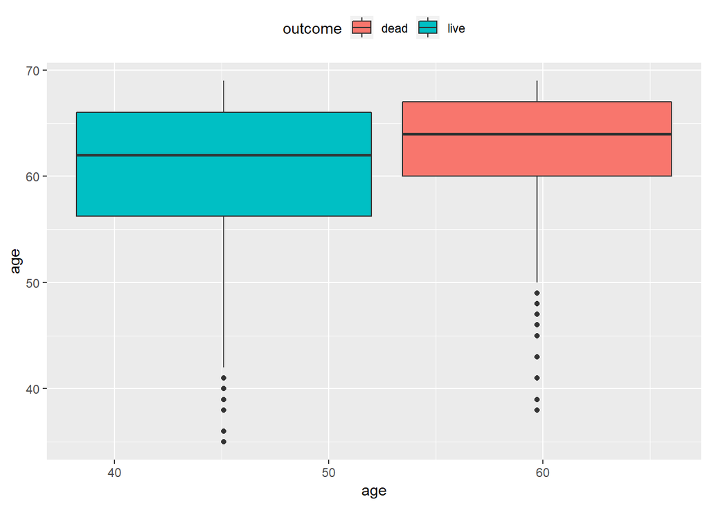

```r
d %>%
  ggplot(aes(age)) +
  geom_boxplot(aes(fill= outcome, y=age)) +
  theme(legend.position = "top")
```

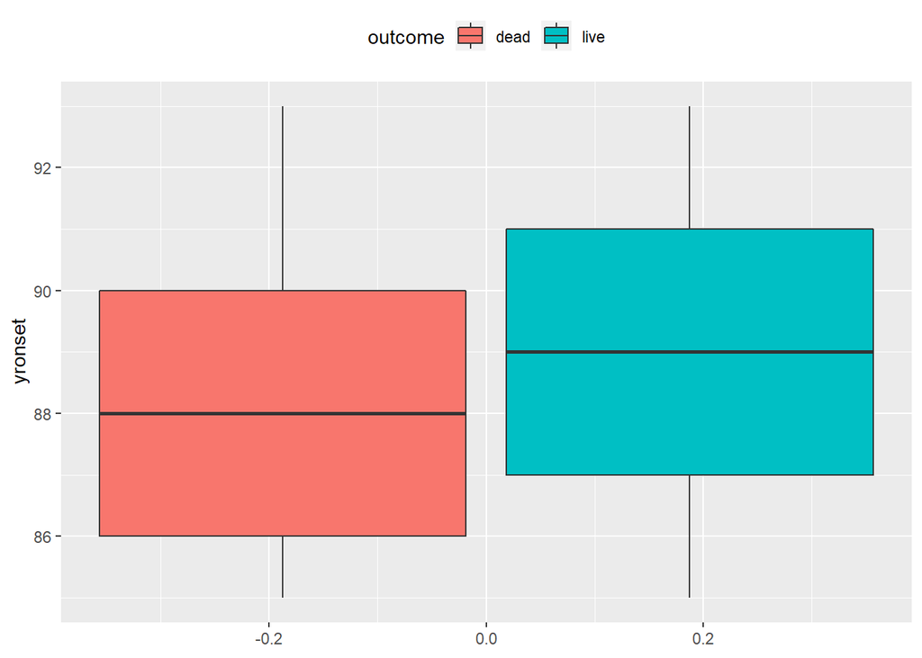

```r
d %>%
  ggplot() +
  geom_boxplot(aes(fill= outcome, y=yronset)) +
  theme(legend.position = "top")
```

2. Propose a statistical model that relates mortality outcome to other variables and estimate its parameters. Logistic regression makes sense for this dataset since we want to predict the outcome which is “yes” or “no”, or success or not. So we will predict the probability of an outcome being “live”.

```r
d <- d %>% mutate_if(is.character,factor)
res <- glm( outcome ~ .  ,family = binomial, data=d)
summary(res)
```

```
##
## Call:
## glm(formula = outcome ~ ., family = binomial, data = d)
##
## Deviance Residuals:
##     Min       1Q   Median       3Q      Max
## -2.4448   0.2794   0.5373   0.6812   2.6390
##
## Coefficients:
##              Estimate Std. Error z value Pr(>|z|)
## (Intercept) -1.130555   2.770390  -0.408 0.683211
## age         -0.043014   0.012533  -3.432 0.000599 ***
## yronset      0.061270   0.030461   2.011 0.044276 *
## premink     -0.631568   0.520903  -1.212 0.225341
## premiy      -0.260398   0.183062  -1.422 0.154893
## smstatn     -0.304231   0.190222  -1.599 0.109745
## smstatnk    -1.159068   0.359971  -3.220 0.001282 **
## smstatx      0.000196   0.224037   0.001 0.999302
## diabetesnk   0.200313   0.720694   0.278 0.781054
## diabetesy   -0.256957   0.181080  -1.419 0.155892
## highbpnk    -1.440612   0.522505  -2.757 0.005831 **
## highbpy      0.157070   0.167067   0.940 0.347136
## hicholnk     0.286884   0.273876   1.047 0.294871
## hicholy      0.503253   0.172743   2.913 0.003576 **
## anginank    -1.848065   0.395234  -4.676 2.93e-06 ***
## anginay     -0.272632   0.170814  -1.596 0.110471
## strokenk    -1.049940   0.584069  -1.798 0.072236 .
## strokey     -0.537003   0.207802  -2.584 0.009760 **
## ---
## Signif. codes:  0 '***' 0.001 '**' 0.01 '*' 0.05 '.' 0.1 ' ' 1
##
## (Dispersion parameter for binomial family taken to be 1)
##
##     Null deviance: 1450.4  on 1294  degrees of freedom
## Residual deviance: 1172.6  on 1277  degrees of freedom
## AIC: 1208.6
##
## Number of Fisher Scoring iterations: 5
```

```r
res2 <- step(res)
```

```
## Start:  AIC=1208.64
## outcome ~ age + yronset + premi + smstat + diabetes + highbp +
##     hichol + angina + stroke
##
##            Df Deviance    AIC
## - diabetes  2   1174.8 1206.8
## - premi     2   1175.7 1207.7
## <none>          1172.6 1208.6
## - yronset   1   1176.7 1210.7
## - hichol    2   1181.5 1213.5
## - stroke    2   1181.6 1213.6
## - smstat    3   1185.3 1215.3
## - highbp    2   1183.5 1215.5
## - age       1   1185.3 1219.3
## - angina    2   1194.3 1226.3
##
## Step:  AIC=1206.76
## outcome ~ age + yronset + premi + smstat + highbp + hichol +
##     angina + stroke
##
##           Df Deviance    AIC
## - premi    2   1178.0 1206.0
## <none>         1174.8 1206.8
## - yronset  1   1178.4 1208.4
## - hichol   2   1184.0 1212.0
## - stroke   2   1184.8 1212.8
## - highbp   2   1185.8 1213.8
## - smstat   3   1188.3 1214.3
## - age      1   1187.2 1217.2
## - angina   2   1196.3 1224.3
##
## Step:  AIC=1205.97
## outcome ~ age + yronset + smstat + highbp + hichol + angina +
##     stroke
##
##           Df Deviance    AIC
## <none>         1178.0 1206.0
## - yronset  1   1181.9 1207.9
## - hichol   2   1186.8 1210.8
## - stroke   2   1188.5 1212.5
## - highbp   2   1189.3 1213.3
## - smstat   3   1191.8 1213.8
## - age      1   1190.6 1216.6
## - angina   2   1204.6 1228.6
```

```r
anova(res2,res, test="LRT")
```

```
## Analysis of Deviance Table
##
## Model 1: outcome ~ age + yronset + smstat + highbp + hichol + angina +
##     stroke
## Model 2: outcome ~ age + yronset + premi + smstat + diabetes + highbp +
##     hichol + angina + stroke
##   Resid. Df Resid. Dev Df Deviance Pr(>Chi)
## 1      1281     1178.0
## 2      1277     1172.6  4   5.3253   0.2555
```

Step function chose the factors age, yronset, smstat, highbp, hichol, angina and stroke. LRT test shows that p value is high enough to fail to reject the small model. So, we will go with it.

3. Assess the goodness of fit of your model. We will apply *Hosmer-Lemeshow test*.

```r
contrasts(d$outcome)
```

```
##      live
## dead    0
## live    1
```

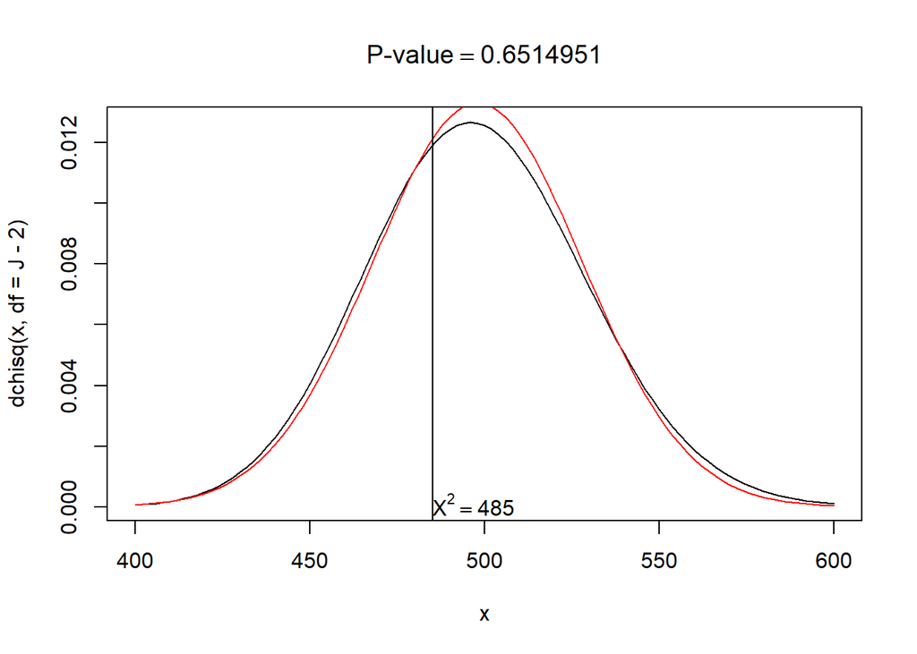

```r
J <- 500

x2 <- list(d,
     data_frame(phat =predict(res2, type="response"))) %>%
  bind_cols() %>%
  as_tibble() %>%
  mutate(bin = cut(phat,
                   breaks=
                     unique(quantile(phat, prob= seq(J)/(J+1))))) %>%
  group_by(bin) %>%
  summarize(phat = mean(phat),
            m = n(),
            y = sum(outcome=="live")) %>%
  mutate(term = (y-m*phat)^2/m/phat/(1-phat)) %>%
  summarize(x2=sum(term)) %>%
  extract2("x2")

pval <- pchisq(x2, df=J-2, lower.tail = FALSE)

curve(dchisq(x, df=J-2), xlim=c(400, 600))
curve(dnorm(x, 498, 30), add=TRUE, col="red")
title(bquote("P-value" == .(pval)))
mtext(side=1, line=-1, at=x2, text=bquote(X^2 == .(round(x2))), adj=0)
abline(v=x2)
```

```r
pval
```

```
## [1] 0.6514951
```

The p-value of Hosmer-Lemeshow test is 0.6515, which is larger than any reasonable significance level. Therefore, we cannot reject the currect model; it fits faily well.

4. Predict the death probability of a patient whose complaints start in 1988 at age 60, and has diabetes, high blood pressure and high cholesterol, but we know nothing else about her. Give a 90% confidence interval.

Chosen factors for the model are age, yronset, smstat, highbp, hichol, angina and stroke. We will use those if given.

```r
newd <- data.frame(yronset=88, age = 60, smstat="nk", highbp = "y", hichol = "y", angina = "nk", stroke = "nk") %>%
  mutate_if(is.character, factor)

predict(res2, newdata = newd , interval = "confidence", level=0.90)
```

```
##         1
## -1.833556
```

I am not sure why the result is like this :(.

5. What are the factors that seem to be associated with the mortality outcome according to your model? Explain.

```r
summary(res2)
```

```
##
## Call:
## glm(formula = outcome ~ age + yronset + smstat + highbp + hichol +
##     angina + stroke, family = binomial, data = d)
##
## Deviance Residuals:
##     Min       1Q   Median       3Q      Max
## -2.4062   0.2781   0.5418   0.6815   2.5308
##
## Coefficients:
##             Estimate Std. Error z value Pr(>|z|)
## (Intercept) -1.00755    2.74191  -0.367 0.713275
## age         -0.04268    0.01244  -3.429 0.000605 ***
## yronset      0.05943    0.03012   1.973 0.048516 *
## smstatn     -0.35150    0.18723  -1.877 0.060468 .
## smstatnk    -1.20574    0.35512  -3.395 0.000686 ***
## smstatx     -0.05989    0.22025  -0.272 0.785690
## highbpnk    -1.48342    0.51388  -2.887 0.003893 **
## highbpy      0.13095    0.16630   0.787 0.431038
## hicholnk     0.27512    0.27207   1.011 0.311918
## hicholy      0.50103    0.17192   2.914 0.003564 **
## anginank    -1.91851    0.38645  -4.965 6.89e-07 ***
## anginay     -0.39384    0.15743  -2.502 0.012359 *
## strokenk    -1.00272    0.51097  -1.962 0.049718 *
## strokey     -0.57867    0.20511  -2.821 0.004783 **
## ---
## Signif. codes:  0 '***' 0.001 '**' 0.01 '*' 0.05 '.' 0.1 ' ' 1
##
## (Dispersion parameter for binomial family taken to be 1)
##
##     Null deviance: 1450.4  on 1294  degrees of freedom
## Residual deviance: 1178.0  on 1281  degrees of freedom
## AIC: 1206
##
## Number of Fisher Scoring iterations: 5
```

My model includes age, yronset, smstat, highbp, hichol, angina and stroke. We cannot decide on by looking to the p-values of the factors in the summary since they are dummy variables and should be considered as a whole. So by step function, associated factors chosen as age, yronset, smstat, highbp, hichol, angina and stroke.

6. Do the effects of smoking habit, high blood pressure, and high cholesterol on the risk of death interact? Explain.

```r
d %>% mutate(inter = interaction(d$smstat, d$highbp, d$hichol) ) %>% xtabs(~outcome + inter,.)
```

```
##        inter
## outcome c.n.n n.n.n nk.n.n x.n.n c.nk.n n.nk.n nk.nk.n x.nk.n c.y.n n.y.n
##    dead    16    25      5    13      0      1       1      0    21    41
##    live   103    61      3    39      0      1       0      0    94   136
##        inter
## outcome nk.y.n x.y.n c.n.nk n.n.nk nk.n.nk x.n.nk c.nk.nk n.nk.nk nk.nk.nk
##    dead      4    21      1      2       0      1       4       5       51
##    live      1    69      7      9       2      3       0       3        0
##        inter
## outcome x.nk.nk c.y.nk n.y.nk nk.y.nk x.y.nk c.n.y n.n.y nk.n.y x.n.y
##    dead       3      5     11      13      4     4     7      0     4
##    live       2     10     23      18     11    49    35      0    17
##        inter
## outcome c.nk.y n.nk.y nk.nk.y x.nk.y c.y.y n.y.y nk.y.y x.y.y
##    dead      1      0       1      1    11    31      2    11
##    live      1      0       0      1    63   131      2    80
```

```r
d %>% mutate(inter = interaction(d$highbp, d$hichol) ) %>% xtabs(~outcome + inter,.)
```

```
##        inter
## outcome n.n nk.n y.n n.nk nk.nk y.nk n.y nk.y y.y
##    dead  59    2  87    4    63   33  15    3  55
##    live 206    1 300   21     5   62 101    2 276
```

```r
res3 <- glm(outcome ~ age + yronset + smstat * highbp * hichol + angina + stroke,
                     data=d,
                     family = "binomial")
anova(res2,res3, test="LRT")
```

```
## Analysis of Deviance Table
##
## Model 1: outcome ~ age + yronset + smstat + highbp + hichol + angina +
##     stroke
## Model 2: outcome ~ age + yronset + smstat * highbp * hichol + angina +
##     stroke
##   Resid. Df Resid. Dev Df Deviance Pr(>Chi)
## 1      1281     1178.0
## 2      1255     1218.1 26  -40.113
```

They do not seem to be interacting and model with their interaction terms gives a worse result than my model.

7. Estimate the prediction error of your model on unseen data.

```r
nfold <- 10
fold.id <- rep(1:10, len=nrow(d)) %>% sample

error.rate <- rep(NA, nfold)
fn.rate <- rep(NA, nfold)

for (i in seq(nfold)){
  glmod.train <- glm(outcome ~ age + yronset + smstat + highbp + hichol + angina + stroke,
                     data=filter(d, fold.id!=i),
                     family = "binomial")
  preds <- predict(glmod.train,
                   newdata=filter(d, fold.id==i),
                   type="response")
  cls <- c("dead","live")[1+(preds>.5)]
  cnfsn.tbl <- table(obs=filter(d, fold.id==i)$outcome,
                     preds=cls)
  error.rate[i] <- prop.table(cnfsn.tbl) %>%
    diag %>% sum %>% {1-.}
  fn.rate[i] <- prop.table(cnfsn.tbl,1)["dead","live"]
}

merr <- error.rate %>% mean
sderr <- error.rate %>% sd

merr
```

```
## [1] 0.1984019
```

```r
sderr
```

```
## [1] 0.02577332
```